# Soluções: Atividade Prática 2

Econometria Aplicada à Finanças  
Mestrado Profissional em Administração

Autor

Prof. Dr. Washington S. da Silva

Data de Publicação

25 de agosto de 2026

## Questão 1

**a.**

**DicaResposta**

Se $\hat{\beta}$ for um estimador viesado de $\beta$, então, em média, $\hat{\beta}$ não é igual a $\beta$.

**b.**

**DicaResposta**

Sendo $\hat \beta$ um estimador de um parâmetro populacional $\beta$, podemos definir formalmente (ou seja, matematicamente) o viés como:

$$\text{Viés}\left(\hat\beta\right) = \mathop{E}\left[ \hat\beta \right] - \beta$$

**c.**

**DicaResposta**

Se um estimador for viesado, ele estimará sistematicamente o valor errado do parâmetro de interesse, o que torna mais difícil aprender sobre esse parâmetro desconhecido que estamos tentando estimar.

**d.**

**DicaResposta**

Os estimadores $B$ e $C$ são não viesados, visto que $E[B]= \beta$, $E[C]= \beta$.

**e.**

**DicaResposta**

**f.**

**DicaResposta**

**g.**

**DicaResposta**

Erro padrão é o desvio padrão da distribuição amostral (ou de amostragem) de um estimador, e nos ajuda a entender o quão preciso é um estimador.

**h.**

**DicaResposta**

Verdadeiro, com uma ressalva. A ausência de viés é uma propriedade definida para determinado tamanho de amostra:

$$\operatorname{E}\left(\widehat{\beta}_n\right)=\beta.$$

A consistência é uma propriedade assintótica: à medida que o tamanho da amostra aumenta, o estimador converge em probabilidade para o parâmetro populacional,

$$\widehat{\beta}_n \xrightarrow{p} \beta.$$

Assim, um estimador pode ser viesado em amostras finitas e, ainda assim, ser consistente, desde que seu viés e sua variabilidade desapareçam quando o tamanho da amostra aumenta.

## Questão 2

```r
# Define o caminho relativo do arquivo CSV.
caminho_csv <- "../../../data/raw/data-ps1.csv"

# Importa os dados.
life_df <- readr::read_csv(caminho_csv, show_col_types = FALSE)

# Inspeciona a estrutura dos dados.
dplyr::glimpse(life_df)
```

```
Rows: 3,106
Columns: 18
$ county_name       <chr> "Autauga", "Autauga", "Baldwin", "Baldwin", "Barbour…
$ county_code       <dbl> 1001, 1001, 1003, 1003, 1005, 1005, 1009, 1009, 1015…
$ state_abb         <chr> "AL", "AL", "AL", "AL", "AL", "AL", "AL", "AL", "AL"…
$ income_quartile   <dbl> 1, 4, 1, 4, 1, 4, 1, 4, 1, 4, 1, 4, 1, 4, 1, 4, 1, 4…
$ life_exp          <dbl> 76.360, 84.215, 79.535, 86.270, 79.733, 86.653, 78.5…
$ pct_uninsured     <dbl> 0.13601, 0.13601, 0.19085, 0.19085, 0.18514, 0.18514…
$ poverty_rate      <dbl> 0.10923, 0.10923, 0.10147, 0.10147, 0.26800, 0.26800…
$ pct_religious     <dbl> 0.56113, 0.56113, 0.47243, 0.47243, 0.41170, 0.41170…
$ pct_black         <dbl> 0.1700900, 0.1700900, 0.1022469, 0.1022469, 0.460396…
$ pct_hispanic      <dbl> 0.0139681, 0.0139681, 0.0175622, 0.0175622, 0.016461…
$ unemployment_rate <dbl> 0.037379, 0.037379, 0.039112, 0.039112, 0.068132, 0.…
$ median_hh_inc     <dbl> 34.380, 34.380, 39.220, 39.220, 24.274, 24.274, 30.2…
$ is_urban          <dbl> 1, 1, 1, 1, 0, 0, 1, 1, 1, 1, 1, 1, 1, 1, 1, 1, 1, 1…
$ pop               <dbl> 43671, 43671, 140415, 140415, 29038, 29038, 51024, 5…
$ pop_density       <dbl> 73.277, 73.277, 87.960, 87.960, 32.815, 32.815, 79.0…
$ pct_smoke         <dbl> 0.333333, 0.133333, 0.268097, 0.176991, 0.228571, 0.…
$ pct_obese         <dbl> 0.37500, 0.13333, 0.29805, 0.13575, 0.29412, 0.27778…
$ pct_exercise      <dbl> 0.50000, 0.80000, 0.59943, 0.83796, 0.54286, 0.72222…
```

## Conheça os dados

Como em qualquer análise de dados, o primeiro passo é conhecer os dados com os quais iremos trabalhar.

**a.** Use `R` para informar:

- o número de observações;
- o número de variáveis;
- o número de observações completas;
- o número de condados distintos;
- o número de estados distintos;
- o número de observações em cada quartil de renda;
- o número de valores ausentes em cada variável.

**DicaResposta**

```r
# Informa, separadamente, as dimensões e contagens solicitadas.
nrow(life_df)
```

```
[1] 3106
```

```r
ncol(life_df)
```

```
[1] 18
```

```r
sum(complete.cases(life_df))
```

```
[1] 3106
```

```r
dplyr::n_distinct(life_df$county_code)
```

```
[1] 1554
```

```r
dplyr::n_distinct(life_df$state_abb)
```

```
[1] 50
```

```r
# Observações por quartil de renda
life_df |>
  count(income_quartile)
```

```
# A tibble: 2 × 2
  income_quartile     n
            <dbl> <int>
1               1  1553
2               4  1553
```

```r
# Conta diretamente os valores ausentes de cada variável.
colSums(is.na(life_df))
```

```
      county_name       county_code         state_abb   income_quartile
                0                 0                 0                 0
         life_exp     pct_uninsured      poverty_rate     pct_religious
                0                 0                 0                 0
        pct_black      pct_hispanic unemployment_rate     median_hh_inc
                0                 0                 0                 0
         is_urban               pop       pop_density         pct_smoke
                0                 0                 0                 0
        pct_obese      pct_exercise
                0                 0
```

O conjunto de dados possui 3106 observações e 18 variáveis. Há 3106 observações completas. Portanto, não precisamos excluir nenhuma observação devido à presença de valores ausentes.

**b.** Crie uma nova variável denominada `high_income`, que seja igual a `1` quando `income_quartile == 4` e igual a `0` caso contrário.

**DicaResposta**

```r
# Cria o indicador de alta renda
life_df <- life_df |>
  dplyr::mutate(
    high_income = dplyr::if_else(income_quartile == 4, 1, 0)
  )
```

**c.** Construa uma tabela de estatísticas descritivas que apresente a média e o desvio-padrão das seguintes variáveis para cada grupo de renda:

- expectativa de vida (`life_exp`);
- taxa de tabagismo (`pct_smoke`);
- taxa de obesidade (`pct_obese`);
- taxa de prática de exercícios físicos (`pct_exercise`).

**DicaResposta**

```r
# Estatísticas descritivas por quartil de renda
life_df |>
  dplyr::group_by(income_quartile) |>
  dplyr::summarize(
    media_vida = mean(life_exp),
    dp_vida = sd(life_exp),
    media_tabagismo = mean(pct_smoke),
    dp_tabagismo = sd(pct_smoke),
    media_obesidade = mean(pct_obese),
    dp_obesidade = sd(pct_obese),
    media_exercicio = mean(pct_exercise),
    dp_exercicio = sd(pct_exercise)
  )
```

```
# A tibble: 2 × 9
  income_quartile media_vida dp_vida media_tabagismo dp_tabagismo
            <dbl>      <dbl>   <dbl>           <dbl>        <dbl>
1               1       78.9    1.45           0.281       0.0796
2               4       86.0    1.37           0.130       0.0791
# ℹ 4 more variables: media_obesidade <dbl>, dp_obesidade <dbl>,
#   media_exercicio <dbl>, dp_exercicio <dbl>
```

O grupo de maior renda apresenta expectativa de vida média consideravelmente mais elevada, menores taxas de tabagismo e obesidade e maior taxa de prática de exercícios físicos. Esses padrões sugerem que o grupo de renda está relacionado tanto aos comportamentos associados à saúde quanto à expectativa de vida.

## Visualize os dados

Antes de estimarmos os modelos de regressão, vamos visualizar algumas relações importantes presentes nos dados.

**d.** Construa boxplots lado a lado (`geom_boxplot`) da expectativa de vida (`life_exp`) por quartil de renda (`income_quartile`). Separe os gráficos de acordo com a condição urbana do condado (`is_urban`).

**DicaResposta**

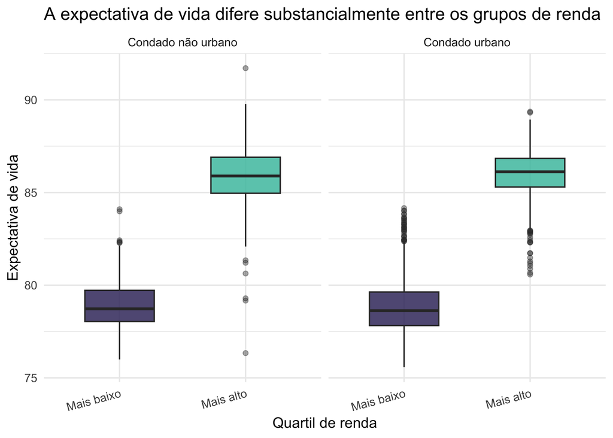

Expectativa de vida por grupo de renda e condição urbana

```r
# Boxplots da expectativa de vida por grupo de renda e condição urbana
ggplot(
  data = life_df,
  aes(x = factor(income_quartile), y = life_exp, fill = factor(income_quartile))
) +
geom_boxplot(width = 0.55, alpha = 0.85, outlier.alpha = 0.4) +
facet_wrap(
  ~ is_urban,
  labeller = as_labeller(c('0' = 'Condado não urbano', '1' = 'Condado urbano'))
) +
scale_y_continuous('Expectativa de vida', labels = scales::comma) +
scale_x_discrete(
  'Quartil de renda',
  labels = c('1' = 'Mais baixo', '4' = 'Mais alto')
) +
scale_fill_viridis_d(
  option = 'mako',
  begin = 0.25,
  end = 0.75,
  guide = 'none'
) +
labs(title = 'A expectativa de vida difere substancialmente entre os grupos de renda') +
theme_minimal(base_size = 12) +
theme(axis.text.x = element_text(angle = 15, hjust = 1))
```

**e.** Construa um gráfico de densidade das taxas de tabagismo (`pct_smoke`) de acordo com o quartil de renda (`income_quartile`).

**DicaResposta**

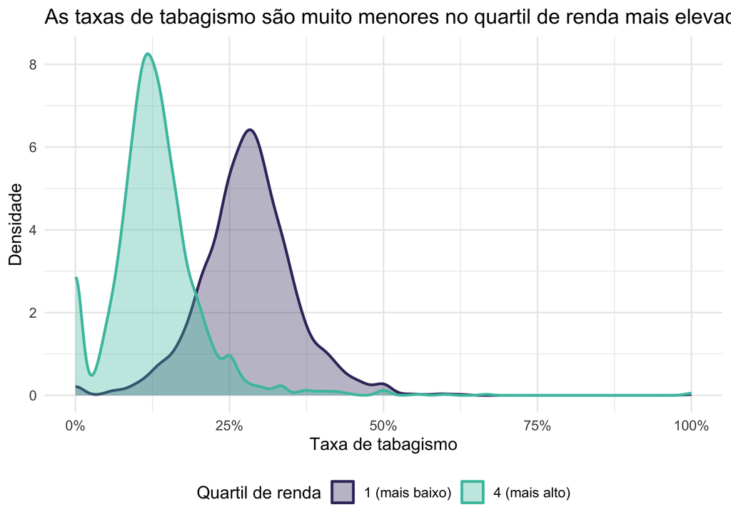

Taxas de tabagismo por grupo de renda

```r
# Gráfico de densidade das taxas de tabagismo por grupo de renda
ggplot(
  data = life_df,
  aes(x = pct_smoke, color = factor(income_quartile), fill = factor(income_quartile))
) +
geom_density(alpha = 0.35, linewidth = 0.9) +
scale_x_continuous('Taxa de tabagismo', labels = scales::percent) +
scale_y_continuous('Densidade', labels = scales::comma) +
scale_color_viridis_d(
  name = 'Quartil de renda',
  labels = c('1 (mais baixo)', '4 (mais alto)'),
  option = 'mako',
  begin = 0.25,
  end = 0.75
) +
scale_fill_viridis_d(
  name = 'Quartil de renda',
  labels = c('1 (mais baixo)', '4 (mais alto)'),
  option = 'mako',
  begin = 0.25,
  end = 0.75
) +
labs(title = 'As taxas de tabagismo são muito menores no quartil de renda mais elevado') +
theme_minimal(base_size = 12) +
theme(legend.position = 'bottom')
```

**f.** Construa um gráfico de dispersão relacionando a expectativa de vida (`life_exp`, no eixo *y*) e a taxa de tabagismo (`pct_smoke`, no eixo *x*). Utilize cores diferentes para representar os quartis de renda (`income_quartile`) e adicione uma reta de regressão linear separada para cada quartil de renda.

*Dicas*

1. Utilize a estética `color` para diferenciar os pontos de acordo com o quartil de renda.
2. Adicione `geom_smooth(method = 'lm', se = FALSE)` para incluir as retas de regressão linear ajustadas.

**DicaResposta**

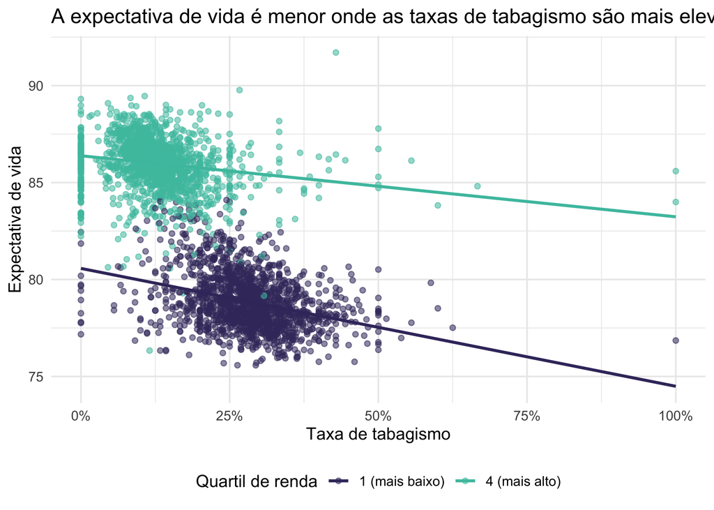

Expectativa de vida e taxas de tabagismo por grupo de renda

```r
# Gráfico de dispersão entre expectativa de vida e taxa de tabagismo
ggplot(
  data = life_df,
  aes(x = pct_smoke, y = life_exp, color = factor(income_quartile))
) +
geom_point(alpha = 0.55, size = 1.5) +
geom_smooth(method = 'lm', se = FALSE, linewidth = 1) +
scale_x_continuous('Taxa de tabagismo', labels = scales::percent) +
scale_y_continuous('Expectativa de vida', labels = scales::comma) +
scale_color_viridis_d(
  name = 'Quartil de renda',
  labels = c('1 (mais baixo)', '4 (mais alto)'),
  option = 'mako',
  begin = 0.25,
  end = 0.75
) +
labs(title = 'A expectativa de vida é menor onde as taxas de tabagismo são mais elevadas') +
theme_minimal(base_size = 12) +
theme(legend.position = 'bottom')
```

**g.** Sintetize os resultados apresentados nos gráficos das questões **d.**, **e.** e **f.**. O que eles sugerem sobre a relação entre expectativa de vida, tabagismo e renda?

**DicaResposta**

Os gráficos mostram uma diferença expressiva na expectativa de vida entre os quartis de renda mais baixo e mais alto. Eles também mostram que as taxas de tabagismo são consideravelmente maiores no quartil de renda mais baixo. O gráfico de dispersão revela uma relação negativa entre tabagismo e expectativa de vida. Entretanto, ele também mostra que o grupo de renda está relacionado às duas variáveis, o que exige cautela ao interpretar a relação simples entre tabagismo e expectativa de vida como uma relação causal.

## Viés de variável omitida

Suponha que estejamos interessados em estimar a relação entre tabagismo e expectativa de vida:

$$\text{(Expectativa de vida)}_i = \beta_0 + \beta_1 \text{(Taxa de tabagismo)}_i + u_i.$$

**h.** Explique por que o gráfico de dispersão construído na questão **f.** sugere que o viés de variável omitida pode ser uma preocupação na estimação dessa regressão.

**DicaResposta**

O grupo de renda parece estar correlacionado tanto com a taxa de tabagismo quanto com a expectativa de vida. As observações correspondentes ao grupo de menor renda tendem a apresentar taxas de tabagismo mais elevadas e menor expectativa de vida. Se o grupo de renda afeta a expectativa de vida e for omitido da regressão, seus efeitos passam a fazer parte do termo de erro. Como o grupo de renda também está correlacionado com a taxa de tabagismo, a hipótese de exogeneidade não é satisfeita, gerando viés de variável omitida.

**i.** Com base nos sinais das relações observadas na questão **f.**, você espera que a omissão do grupo de renda produza um viés para cima ou para baixo na estimativa de MQO de $\beta_1$? Explique seu raciocínio.

**DicaResposta**

Espera-se um viés para baixo, o que significa que o coeficiente associado ao tabagismo será excessivamente negativo. Maior renda está associada a menores taxas de tabagismo; portanto, a relação entre tabagismo e alta renda é negativa. Ao mesmo tempo, maior renda está associada a maior expectativa de vida; portanto, o efeito da variável omitida sobre a expectativa de vida é positivo. O produto dessas duas relações é negativo, o que implica um viés para baixo na estimativa do coeficiente associado ao tabagismo.

**j.** Estime as duas regressões apresentadas a seguir e forneça uma tabela com os resultados:

1. A regressão simples, contendo apenas a taxa de tabagismo:

$$\text{(Expectativa de vida)}_i = \beta_0 + \beta_1 \text{(Taxa de tabagismo)}_i + u_i;$$

2. A regressão que também controla para alta renda:

$$\text{(Expectativa de vida)}_i = \beta_0 + \beta_1 \text{(Taxa de tabagismo)}_i + \beta_2 \text{(Alta renda)}_i + u_i.$$

**DicaResposta**

```r
# Estima as regressões com e sem o indicador de alta renda.
model_simple <- stats::lm(life_exp ~ pct_smoke, data = life_df)
model_income <- stats::lm(
  life_exp ~ pct_smoke + high_income,
  data = life_df
)

# Reúne os resultados dos dois modelos em uma única tabela.
resultados_modelos <- dplyr::bind_rows(
  "Modelo simples" = broom::tidy(model_simple),
  "Com alta renda" = broom::tidy(model_income),
  .id = "modelo"
)

resultados_modelos |>
  dplyr::select(modelo, term, estimate, std.error, statistic, p.value) |>
  knitr::kable(digits = 2)
```

| modelo | term | estimate | std.error | statistic | p.value |
| --- | --- | --- | --- | --- | --- |
| Modelo simples | (Intercept) | 87.51 | 0.10 | 852.10 | 0 |
| Modelo simples | pct_smoke | -24.81 | 0.44 | -56.18 | 0 |
| Com alta renda | (Intercept) | 80.16 | 0.09 | 860.96 | 0 |
| Com alta renda | pct_smoke | -4.62 | 0.31 | -15.01 | 0 |
| Com alta renda | high_income | 6.41 | 0.07 | 95.07 | 0 |

**k.** Compare as estimativas de $\beta_1$ obtidas nas duas regressões da questão **j.**. A mudança observada é consistente com sua previsão na questão **i.**? Interprete os coeficientes considerando um aumento de **10 pontos percentuais** na taxa de tabagismo.

**DicaResposta**

O coeficiente associado ao tabagismo muda de -24.81 para -4.62 após controlarmos para alta renda. Para um aumento de 10 pontos percentuais na taxa de tabagismo, o modelo simples prevê uma variação de -2.48 ano(s) na expectativa de vida, enquanto o modelo que controla para alta renda prevê uma variação de -0.46 ano(s).

Após controlarmos para o grupo de renda, o coeficiente associado ao tabagismo torna-se substancialmente menos negativo. Esse resultado é consistente com a presença de viés de variável omitida para baixo na regressão simples.

**l.** Agora estime um modelo que controle para a taxa de tabagismo, alta renda e a condição urbana do condado:

$$\text{(Expectativa de vida)}_i = \beta_0 + \beta_1 \text{(Taxa de tabagismo)}_i + \beta_2 \text{(Alta renda)}_i + \beta_3 \text{(Condado urbano)}_i + u_i.$$

A inclusão do indicador de condado urbano altera de maneira relevante a estimativa do coeficiente associado ao tabagismo? Explique o que esse resultado nos revela sobre o viés de variável omitida.

**DicaResposta**

```r
# Estima o modelo com controles para alta renda e condado urbano.
model_main <- stats::lm(
  life_exp ~ pct_smoke + high_income + is_urban,
  data = life_df
)

# Compara diretamente os coeficientes associados ao tabagismo.
stats::coef(model_income)["pct_smoke"]
```

```
pct_smoke
  -4.6232
```

```r
stats::coef(model_main)["pct_smoke"]
```

```
pct_smoke
  -4.6236
```

A inclusão do indicador de condado urbano praticamente não altera a estimativa do coeficiente associado ao tabagismo. Esse resultado é um lembrete importante de que nem toda variável omitida produz um viés de variável omitida relevante. Para que a omissão de uma variável produza viés no coeficiente associado ao tabagismo, essa variável deve estar relacionada à expectativa de vida e, ao mesmo tempo, estar correlacionada com a taxa de tabagismo na amostra.